# ▒ 데이터 설명 ▒

## **0. 환경설정**

```r
library(tidyverse)
library(tm)
library(RColorBrewer)
library(readxl)
```

## **1. 아파트 데이터**

### **[데이터 다운로드]**

- C드라이브에 [R_project] 폴더 생성
- [R_project] 폴더에 [DAT] 폴더 생성
- 데이터 스토어에서 샘플데이터(3.아파트_주소기반_주택지역특성시세정보_DB.xlsx)를 “C:/R_project/DAT/”에 다운로드  
  (https://www.datastore.or.kr/file/detail?id=2c0a9616-4d78-403c-9d77-3db2effb2a74&page=1&viewCount=10&sort=1&order=1&source=1&keyword=%EC%95%84%ED%8C%8C%ED%8A%B8)
- 서울/수도권 및 5대광역시 아파트에 대한 주소테이블 외 4개의 테이블(정보집단)로 구성되며 각각 주택특성정보, 지역특성정보, 가격/신뢰등급/예상회수율정보 테이블로 이루어져 있고, 각 테이블간은 고유키값(NUM)으로 연계되어 있음
- (주소테이블) 주소테이블에는 법정동, 도로명, 건물명, 동명, 호명 등 19개항목으로 구성되어 있고, 제공되는 데이터 정보는 총 83개항목으로 구성되어 있으며, 세부내역은 아래와 같습니다.
- (주택특성) 세대수, 주차수, 사용승인, 내진설계여부, 면적(전유면적, 공유면적 등), 용도지역, 도로접면, 혐오시설과의 거리, 지세, 형상, 재개발재건축여부, 인근지하철명, 지하철과의 거리 등 29개항목
- (지역특성) 인구수, 가구수, 1인가구수, 주택수, 초과수요, 노후도수준, 주택면적수준, 인근지역거래패턴의견, 본건시장성분석의견, 주거노후도, 교통편리성 등 38개항목
- (시세정보 등) 일반거래시세, 상위거래시세, 하위거래시세, 가격제공불가사유, 거래시세 신뢰등급, 등급의견, 예상낙찰가능금액, 경매집행비용, 감정평가수수료 등 16개 항목

### **[데이터 호출]**

```r
path                  <- "C:/R_project/DAT/3.아파트_주소기반_주택지역특성시세정보_DB.xlsx"
sheet.names           <- excel_sheets(path)

df1                   <- read_excel(path, sheet.names[1])
df2                   <- read_excel(path, sheet.names[2])
df3                   <- read_excel(path, sheet.names[3])
df4                   <- read_excel(path, sheet.names[4])

data                  <- Reduce(function(x, y) merge(x, y, all=FALSE), list(df1, df2, df3, df4))
data
```

| NUM | DATA_DATE | POP_TYPE | PNU | DANJI_CODE | SIDO | SGG | EMD | RI | SAN | BUN1 | BUN2 | BLD_NAME | DONG_NAME | HO_NAME | ROAD_CD | R_ADDRESS | HJD_CODE | HJD_NAME | BLD_DATE | EV | STRUC | ROOF | FLOOR | PRIV_AREA | PUB_AREA | SUM_AREA | USE_CODE | UNIT_NUM | PARK_NUM | … |
| --- | --- | --- | --- | --- | --- | --- | --- | --- | --- | --- | --- | --- | --- | --- | --- | --- | --- | --- | --- | --- | --- | --- | --- | --- | --- | --- | --- | --- | --- | --- |
| G20160002445483 | 20190301 | APT | 1111011500-100090000 | 3 | 서울특별시 | 종로구 | 사직동 | NA | 1 | 9 | 0 | 광화문풍림스페이스본 | 광화문풍림스페이스본101동 | 1409 | 111104100135 | 서울특별시 종로구 사직로8길 4 | 1111053000 | 사직동 | 20080711 | 1 | 철골철근콘크리트구조 | 평스라브 | 14 | 94.51 | 66.27 | 160.78 | NA | 1011 | 1480 | … |
| G20160002445829 | 20190301 | APT | 1111011500-100090000 | 3 | 서울특별시 | 종로구 | 사직동 | NA | 1 | 9 | 0 | 광화문풍림스페이스본 | 광화문풍림스페이스본101동 | 1405 | 111104100135 | 서울특별시 종로구 사직로8길 4 | 1111053000 | 사직동 | 20080711 | 1 | 철골철근콘크리트구조 | 평스라브 | 14 | 126.34 | 88.60 | 214.94 | NA | 1011 | 1480 | … |
| G20160002446017 | 20190301 | APT | 1111011500-100090000 | 3 | 서울특별시 | 종로구 | 사직동 | NA | 1 | 9 | 0 | 광화문풍림스페이스본 | 광화문풍림스페이스본105동 | 202 | 111104100135 | 서울특별시 종로구 사직로8길 4 | 1111053000 | 사직동 | 20080711 | 1 | 철골철근콘크리트구조 | 평스라브 | 2 | 147.31 | 103.30 | 250.61 | NA | 1011 | 1480 | … |
| G20160002446175 | 20190301 | APT | 1111011700-101000000 | 136 | 서울특별시 | 종로구 | 당주동 | NA | 1 | 100 | 0 | NA | NA | 704호 | 111104100190 | 서울특별시 종로구 세종대로23길 54 | 1111053000 | 사직동 | 19830610 | 1 | 철근콘크리트라멘조 | 스라브 | 7 | 105.07 | 13.68 | 118.75 | NA | 72 | 0 | … |
| G20160002446325 | 20190301 | APT | 1111011800-100710000 | 109 | 서울특별시 | 종로구 | 내수동 | NA | 1 | 71 | 0 | NA | 경희궁의아침2단지 | 아파트 606 | 111104100135 | 서울특별시 종로구 사직로8길 24 | 1111053000 | 사직동 | 20040703 | 1 | 철근콘크리트구조 | (철근)콘크리트 | 6 | 140.78 | 100.84 | 241.62 | NA | 462 | 0 | … |
| G20160002446364 | 20190301 | APT | 1111011800-100710000 | 109 | 서울특별시 | 종로구 | 내수동 | NA | 1 | 71 | 0 | NA | 경희궁의아침2단지 | 아파트 605 | 111104100135 | 서울특별시 종로구 사직로8길 24 | 1111053000 | 사직동 | 20040703 | 1 | 철근콘크리트구조 | (철근)콘크리트 | 6 | 140.78 | 100.84 | 241.62 | NA | 462 | 0 | … |
| G20160002446400 | 20190301 | APT | 1111011800-100720000 | 53 | 서울특별시 | 종로구 | 내수동 | NA | 1 | 72 | 0 | NA | 경희궁의아침3단지 | 아파트 305 | 111104100135 | 서울특별시 종로구 사직로8길 34 | 1111053000 | 사직동 | 20040517 | 1 | 철근콘크리트구조 | (철근)콘크리트 | 3 | 149.00 | 105.86 | 254.86 | NA | 767 | 0 | … |
| G20160002446644 | 20190301 | APT | 1111011800-100730000 | 134 | 서울특별시 | 종로구 | 내수동 | NA | 1 | 73 | 0 | NA | 경희궁의아침4단지 | 아파트 1208 | 111104100158 | 서울특별시 종로구 새문안로3길 23 | 1111053000 | 사직동 | 20040517 | 1 | 철근콘크리트구조 | (철근)콘크리트 | 12 | 150.77 | 108.57 | 259.34 | NA | 427 | 0 | … |
| G20160002446995 | 20190301 | APT | 1111013300-100300006 | 92 | 서울특별시 | 종로구 | 익선동 | NA | 1 | 30 | 6 | 운현신화타워 | NA | 1401호 | 111104100147 | 서울특별시 종로구 삼일대로32길 36 | 1111061500 | 종로1.2.3.4가동 | 19980311 | 1 | 철근콘크리트조 | 평슬라브 | 14 | 84.87 | 58.17 | 143.04 | NA | 64 | 0 | … |
| G20160002447027 | 20190301 | APT | 1111013300-100300006 | 92 | 서울특별시 | 종로구 | 익선동 | NA | 1 | 30 | 6 | 운현신화타워 | NA | 806호 | 111104100147 | 서울특별시 종로구 삼일대로32길 36 | 1111061500 | 종로1.2.3.4가동 | 19980311 | 1 | 철근콘크리트조 | 평슬라브 | 8 | 84.91 | 58.19 | 143.10 | NA | 64 | 0 | … |

[output cut: 490 more lines]

## **2. 신용데이터**

### **[데이터 다운로드]**

- C드라이브에 [R_project] 폴더 생성
- [R_project] 폴더에 [DAT] 폴더 생성
- 데이터 스토어에서 샘플데이터(KCB_지역단위_신용분석정보_소비_샘플데이터.xlsx)를 “C:/R_project/DAT/”에 다운로드  
  (https://www.datastore.or.kr/file/detail?id=cb435c94-01aa-4f72-b405-55fd571a7dd1&page=2&viewCount=10&sort=1&order=1&source=1&keyword=KCB)
- 카드(신용카드, 체크카드)를 이용하는 국내 거주자(거주지 주소기준)를 대상으로 수집된 데이터를 기반으로 재작성된 데이터로써 공간적 범위(시도, 시군구, 행정동 및 각종 Block 등)를 기준으로 성별, 연령별, 직업구분(KCB 기준), 카드총이용금액합계 10분위 및 각 분위에 따른 카드이용정보를 담고 있음
- Key : 기준년월, 시도코드, 시도명, 시군구코드, 시군구명, 성별, 연령구간대(10세 단위) 직업구분(0: 전체, 1: 급여소득자, 2: 자영업_일반, 3: 자영업_전문직, 4: 기타), 분위코드(카드 총이용 금액 합계 기준)
- Card : 신용카드 보유고객수, 체크카드 보유고객수, (신용+체크) 보유고객수, 신용카드 이용고객수, 체크카드 이용고객수, (신용+체크) 이용고객수, 카드총이용금액합계, 평균 카드총이용금액합계, 최저 카드총이용금액합계, 최대 카드총이용금액합계, 신용카드 총이용금액합계, 신용카드 일시불이용금액합계, 신용카드 할부이용금액합계, 신용카드 현금서비스이용금액합계, 체크카드 총이용금액합계

### **[데이터 호출]**

```r
path                  <- "C:/R_project/DAT/KCB_지역단위_신용분석정보_소비_샘플데이터.xlsx"
sheet.names           <- excel_sheets(path)
DF                    <- read_excel(path, sheet.names[1], na = c(NA, '', ' - '))
DF
```

| BS_YR_MON | CT_PRVNC_CD | CT_PRVNC_NM | CT_CNTY_GU_CD | CT_CNTY_GU_NM | SEX | AGE_BAND | JOB_GB | NTILE | Card_Index_C01 | Card_Index_C02 | Card_Index_C03 | Card_Index_C04 | Card_Index_C05 | Card_Index_C06 | Card_Index_C07 | Card_Index_C08 | Card_Index_C09 | Card_Index_C10 | Card_Index_C11 | Card_Index_C12 | Card_Index_C13 | Card_Index_C14 | Card_Index_C15 |
| --- | --- | --- | --- | --- | --- | --- | --- | --- | --- | --- | --- | --- | --- | --- | --- | --- | --- | --- | --- | --- | --- | --- | --- |
| 201810 | 11 | 서울특별시 | 11560 | 영등포구 | F | 20 | 1 | 6 | 1135 | 1356 | 1361 | 1087 | 1189 | 1361 | 1654897 | 1216 | 1104 | 1330 | 893821 | 774942 | 115351 | 4667 | 761076 |
| 201810 | 11 | 서울특별시 | 11560 | 영등포구 | M | 70 | 2 | 10 | 222 | 127 | 222 | 221 | 42 | 222 | 2343812 | 10558 | 3607 | 508650 | 2206439 | 1187865 | 771168 | 247710 | 137373 |
| 201810 | 11 | 서울특별시 | 11560 | 영등포구 | F | 30 | 4 | 10 | 1146 | 1204 | 1225 | 1132 | 845 | 1225 | 5244458 | 4281 | 2496 | 57238 | 4102995 | 2617178 | 1002094 | 485536 | 1141462 |
| 201810 | 11 | 서울특별시 | 11560 | 영등포구 | F | 60 | 4 | 3 | 289 | 1455 | 1572 | 38 | 10 | 48 | 25 | 1 | 0 | 1 | 20 | 315 | 0 | 0 | 5 |
| 201810 | 11 | 서울특별시 | 11560 | 영등포구 | F | 30 | 4 | 7 | 903 | 1205 | 1225 | 853 | 972 | 1225 | 1252833 | 1023 | 871 | 1186 | 639939 | 557592 | 80290 | 3198 | 612894 |
| 201810 | 11 | 서울특별시 | 11560 | 영등포구 | M | 20 | 1 | 6 | 753 | 951 | 951 | 707 | 793 | 951 | 1033688 | 1087 | 979 | 1197 | 542150 | 501370 | 34812 | 7140 | 491538 |
| 201810 | 11 | 서울특별시 | 11560 | 영등포구 | F | 50 | 1 | 4 | 1235 | 1160 | 1335 | 1183 | 621 | 1335 | 873061 | 654 | 528 | 783 | 660582 | 560627 | 95178 | 6270 | 212479 |
| 201810 | 11 | 서울특별시 | 11560 | 영등포구 | M | 30 | 1 | 8 | 2589 | 2579 | 2633 | 2566 | 1769 | 2633 | 6534201 | 2482 | 2215 | 2790 | 5319924 | 4603026 | 607822 | 110591 | 1214277 |
| 201810 | 11 | 서울특별시 | 11560 | 영등포구 | F | 20 | 4 | 10 | 1050 | 1464 | 1466 | 1009 | 1311 | 1466 | 3896687 | 2658 | 1624 | 21358 | 2041733 | 1325238 | 550885 | 165991 | 1854954 |
| 201810 | 11 | 서울특별시 | 11560 | 영등포구 | F | 50 | 1 | 9 | 1326 | 1187 | 1334 | 1323 | 611 | 1334 | 4251484 | 3187 | 2597 | 3995 | 3863054 | 2575471 | 1005260 | 284763 | 388430 |

[output cut: 391 more lines]

## **3. 생존 자료분석을 위한 데이터**

### **[Kidney 데이터 호출]**

```r
kidney                <- read.table("c:/R_project/DAT/kidney.txt", header=T, sep="\t")
```

### **[leukemia 데이터 호출]**

```r
data              <- read.table("c:/R_project/DAT/leukemia.txt", header=T, sep=" ")
head(data)
```

|  | group | time1 | time2 | ind1 | ind2 | ind3 | timeA | indA | timeC | indC | timeP | indP | pat.age | donor.age | pat.sex | donor.sex | pat.CMV | donor.CMV | waiting | FAB | hospital | MTX |
| --- | --- | --- | --- | --- | --- | --- | --- | --- | --- | --- | --- | --- | --- | --- | --- | --- | --- | --- | --- | --- | --- | --- |
| 1 | 1 | 2081 | 2081 | 0 | 0 | 0 | 67 | 1 | 121 | 1 | 13 | 1 | 26 | 33 | 1 | 0 | 1 | 1 | 98 | 0 | 1 | 0 |
| 2 | 1 | 1602 | 1602 | 0 | 0 | 0 | 1602 | 0 | 139 | 1 | 18 | 1 | 21 | 37 | 1 | 1 | 0 | 0 | 1720 | 0 | 1 | 0 |
| 3 | 1 | 1496 | 1496 | 0 | 0 | 0 | 1496 | 0 | 307 | 1 | 12 | 1 | 26 | 35 | 1 | 1 | 1 | 0 | 127 | 0 | 1 | 0 |
| 4 | 1 | 1462 | 1462 | 0 | 0 | 0 | 70 | 1 | 95 | 1 | 13 | 1 | 17 | 21 | 0 | 1 | 0 | 0 | 168 | 0 | 1 | 0 |
| 5 | 1 | 1433 | 1433 | 0 | 0 | 0 | 1433 | 0 | 236 | 1 | 12 | 1 | 32 | 36 | 1 | 1 | 1 | 1 | 93 | 0 | 1 | 0 |
| 6 | 1 | 1377 | 1377 | 0 | 0 | 0 | 1377 | 0 | 123 | 1 | 12 | 1 | 22 | 31 | 1 | 1 | 1 | 1 | 2187 | 0 | 1 | 0 |

```r
tail(data)
```

|  | group | time1 | time2 | ind1 | ind2 | ind3 | timeA | indA | timeC | indC | timeP | indP | pat.age | donor.age | pat.sex | donor.sex | pat.CMV | donor.CMV | waiting | FAB | hospital | MTX |
| --- | --- | --- | --- | --- | --- | --- | --- | --- | --- | --- | --- | --- | --- | --- | --- | --- | --- | --- | --- | --- | --- | --- |
| 132 | 3 | 105 | 48 | 1 | 1 | 1 | 105 | 0 | 105 | 0 | 30 | 1 | 17 | 14 | 0 | 1 | 0 | 0 | 210 | 1 | 4 | 0 |
| 133 | 3 | 392 | 273 | 1 | 1 | 1 | 392 | 0 | 122 | 1 | 24 | 1 | 43 | 50 | 1 | 1 | 1 | 0 | 240 | 0 | 3 | 1 |
| 134 | 3 | 63 | 63 | 1 | 0 | 1 | 38 | 1 | 63 | 0 | 16 | 1 | 44 | 37 | 1 | 1 | 0 | 0 | 360 | 1 | 3 | 1 |
| 135 | 3 | 97 | 76 | 1 | 1 | 1 | 97 | 0 | 97 | 0 | 97 | 0 | 48 | 56 | 1 | 1 | 1 | 1 | 330 | 0 | 3 | 1 |
| 136 | 3 | 153 | 113 | 1 | 1 | 1 | 153 | 0 | 153 | 0 | 59 | 1 | 31 | 25 | 0 | 1 | 1 | 1 | 240 | 0 | 3 | 1 |
| 137 | 3 | 363 | 363 | 1 | 0 | 1 | 363 | 0 | 363 | 0 | 19 | 1 | 52 | 48 | 1 | 1 | 1 | 0 | 180 | 0 | 3 | 1 |

## **4. MNIST 데이터**

### **[데이터 다운로드]**

- C드라이브에 [R_project] 폴더 생성
- [R_project] 폴더에 [DAT] 폴더 생성
- yann lecun 홈페이지에서 데이터 다운로드  
  (http://yann.lecun.com/exdb/mnist/)

### **[데이터 호출]**

```r
mnist <- readRDS("C:/R_project/DAT/mnist.RDS") # mnist 데이터 로드
dim(mnist$train$x); dim(mnist$train$y)
```

```
## [1] 60000    28    28
```

```
## [1] 60000
```

```r
dim(mnist$test$x); dim(mnist$test$y)
```

```
## [1] 10000    28    28
```

```
## [1] 10000
```

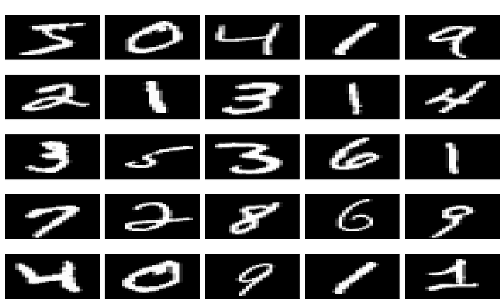

```r
par(mfrow=c(5,5), mai=c(0,0.1,0.3,0)) #margin size (b, l, t, r)
for(n in 1:25){
  image(t(mnist$train$x[n,,])[,28:1], axes=F, col=gray((0:255)/255))
}
```

## **5. Fashion MNIST 데이터**

### **[데이터 다운로드]**

- C드라이브에 [R_project] 폴더 생성
- [R_project] 폴더에 [DAT] 폴더 생성
- 데이터 다운로드  
  (https://github.com/zalandoresearch/fashion-mnist/)

### **[데이터 호출]**

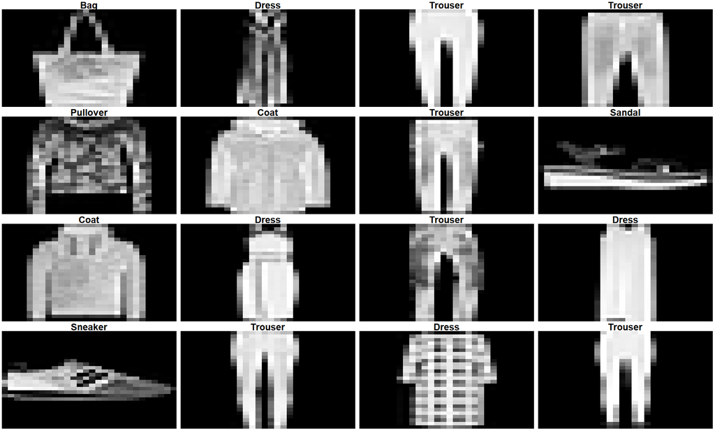

```r
mnist <- readRDS("C:/R_project/DAT/mnist.RDS") # mnist 데이터 로드
train.data <- read.csv("C:/R_project/DAT/fashion-mnist_train.csv", header=T, stringsAsFactors = F)

x_train <- as.matrix(train.data[1:5000, 2:dim(train.data)[2]])
y_train <- as.matrix(train.data[1:5000, 1])
dim(x_train) <- c(nrow(x_train), 28, 28, 1)

#label 명칭 벡터 생성
clothes.labels <-c( "T-shirt/top", "Trouser", "Pullover", "Dress", "Coat",
                    "Sandal", "Shirt", "Sneaker", "Bag", "Ankle boot")

rotate <- function(x) t(apply(x, 2, rev))

#이미지 재작성 및 확인
par(mfrow=c(4, 4), mar=c(0, 0.2, 1, 0.2))
for (i in 1:16) {
  nr <- i * 10
  image(rotate(rotate(x_train[nr, , , 1])), axes = FALSE,
        col = grey(seq(0, 1, length = 256)),
        main = list(clothes.labels[as.numeric(train.data[nr, 1] + 1)]))
}
```

## **6. 전력데이터**

### **[데이터 호출]**

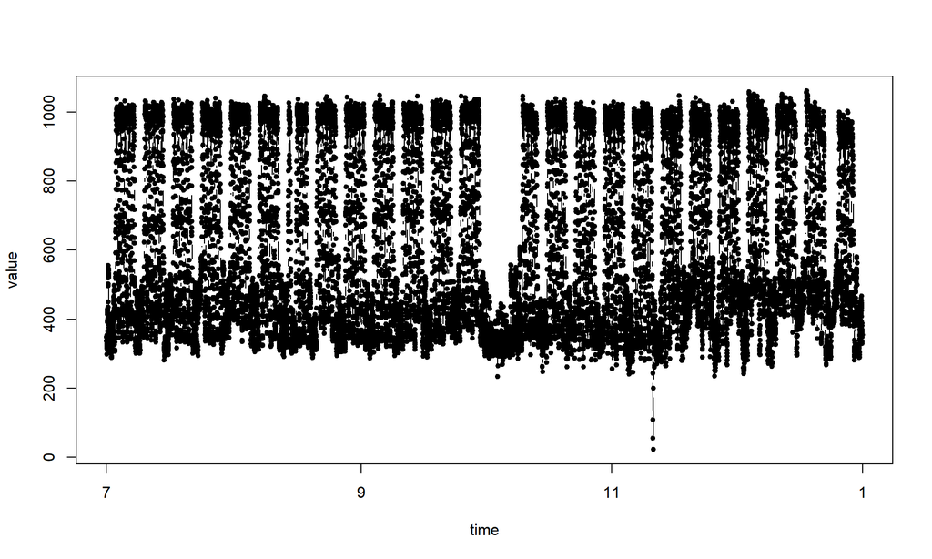

```r
#자료 읽기
data <- read.delim("C:/R_project/DAT/전력수요_시계열자료.txt",header=T,stringsAsFactors = F)

#문자형 시간에 시간 속성 부여
data$time <- as.POSIXct(data$time)

plot(data, type = 'b', pch = 20)
```

## **홍보. 데이터 놀이터 : 데이터 안심구역**

### **[홈페이지]**

https://dsz.kdata.or.kr/svc/main/main.do

### **[가이드 북]**

https://dsz.kdata.or.kr/html/datasafezoneuserguide.pdf